# Reproducible Research: Peer Assessment 1

Nicholai M. Khiterer

6/12/2020

## Introduction

This assignment utilizes data from a personal activity monitoring device. The device collected data at 5 minute intervals through out the day, for two two months, dayly. The data were obtained from an anonymous subject, and were collected in October and November of 2012. The data include the number of steps taken by the subject in 5 minute intervals, each day.

"The data for this assignment can be downloaded from the course web site:https://d396qusza40orc.cloudfront.net/repdata%2Fdata%2Factivity.zip

Dataset: Activity monitoring data [52K] The variables included in this dataset are:

steps: Number of steps taking in a 5-minute interval (missing values are coded as NA) date: The date on which the measurement was taken in YYYY-MM-DD format interval: Identifier for the 5-minute interval in which measurement was taken The dataset is stored in a comma-separated-value (CSV) file and there are a total of 17,568 observations in this dataset." (quoted from the text of the Assingmwent)

## Loading and preprocessing the data

```r
#Reading Data file:
ProjectData<-read.csv("activity.csv", sep=",", header=TRUE, stringsAsFactors=TRUE)
summary(ProjectData)
```

```
##      steps                date          interval
##  Min.   :  0.00   2012-10-01:  288   Min.   :   0.0
##  1st Qu.:  0.00   2012-10-02:  288   1st Qu.: 588.8
##  Median :  0.00   2012-10-03:  288   Median :1177.5
##  Mean   : 37.38   2012-10-04:  288   Mean   :1177.5
##  3rd Qu.: 12.00   2012-10-05:  288   3rd Qu.:1766.2
##  Max.   :806.00   2012-10-06:  288   Max.   :2355.0
##  NA's   :2304     (Other)   :15840
```

# Calculating the total number of steps taken per day:

```r
##Steps taking per day:
DaySteps<- aggregate(steps~date,ProjectData, na.rm=T, sum)
head(DaySteps,3)
```

```
##         date steps
## 1 2012-10-02   126
## 2 2012-10-03 11352
## 3 2012-10-04 12116
```

```r
summary(DaySteps)
```

```
##          date        steps
##  2012-10-02: 1   Min.   :   41
##  2012-10-03: 1   1st Qu.: 8841
##  2012-10-04: 1   Median :10765
##  2012-10-05: 1   Mean   :10766
##  2012-10-06: 1   3rd Qu.:13294
##  2012-10-07: 1   Max.   :21194
##  (Other)   :47
```

# Making a histogram of the total number of steps taken each day:

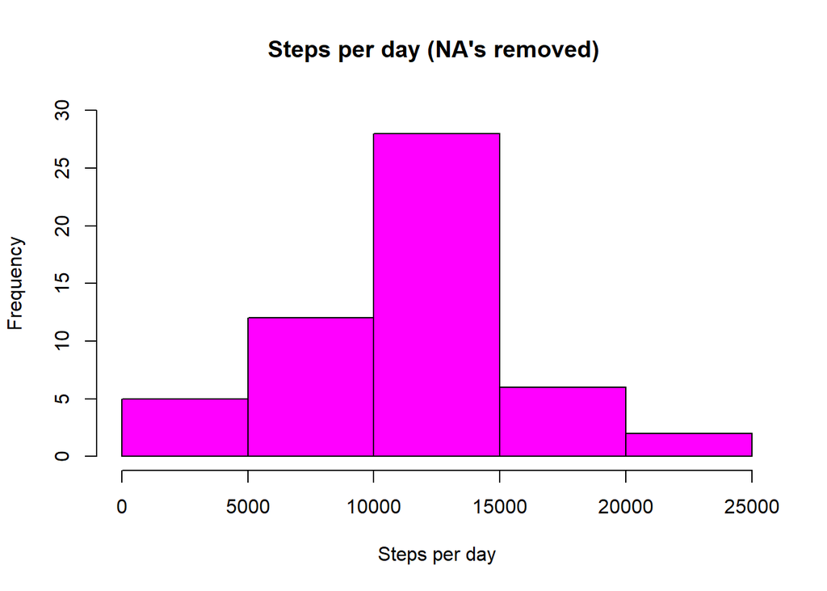

```r
hist(DaySteps$steps, main = "Steps per day (NA's removed) ", xlab = "Steps per day", ylab = "Frequency", ylim=c(0,30), col = "magenta")
```

# Calculating and reporting the mean and median of the total number of steps taken per day:

# Mean of the total number of steps taken per day:

```r
TotalDayStepsMean<-mean(DaySteps$steps,na.rm=TRUE)
TotalDayStepsMean
```

```
## [1] 10766.19
```

# 10766.19

# Median of the total number of steps taken per day:

```r
TotalDayStepsMedian<-median(DaySteps$steps)
TotalDayStepsMedian
```

```
## [1] 10765
```

# 10765

## What is the average daily activity pattern?

Make a time series plot (i.e. type = “l”) of the 5-minute interval (x-axis) and the average number of steps taken, averaged across all days (y-axis)":

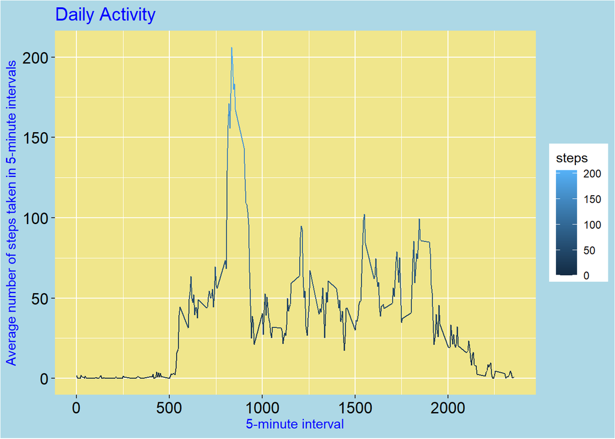

```r
library(ggplot2)
DaylyActivity<- aggregate(steps~interval , ProjectData, mean)

p<- ggplot(DaylyActivity, aes(interval,steps,color=steps))+ ggtitle("Daily Activity")
p + geom_line(size=.5)+labs(x = "5-minute interval")+labs(y = "Average number of steps taken in 5-minute intervals" ) +theme(axis.text=element_text(color="black",size=13))+theme(panel.background=element_rect(fill="khaki"))+theme(axis.title.x=element_text(color='blue',vjust=1.5),axis.title.y=element_text(color="blue",vjust=1.5), plot.title=element_text(color="blue",size=15,vjust=1),
plot.background=element_rect(fill="lightblue"))
```

```r
# plot(plotname)
```

# Which 5-minute interval, on average across all the days in the dataset, contains the maximum number of steps?

```r
maxStepsIndex <- which(DaylyActivity$steps == max(DaylyActivity$steps))
maxNumberStepsInterval <-DaylyActivity$interval[maxStepsIndex]
maxNumberStepsInterval
```

```
## [1] 835
```

# 835

## Imputing missing values:

# Calculating and reporting the total number of missing values in the dataset (i.e. the total number of rows with NAs):

```r
summary(is.na(ProjectData))
```

```
##    steps            date          interval
##  Mode :logical   Mode :logical   Mode :logical
##  FALSE:15264     FALSE:17568     FALSE:17568
##  TRUE :2304
```

#There are 2304 NA’s in step variable, in initial dataset ProjectData, and 0 NAs in date and 0 NA’s in interval columns

##Devise a strategy for filling in all of the missing values in the dataset. The strategy does not need to be sophisticated:

To devise a strategy for filling missing values in the dataset the article “Tutorial on 5 Powerful R Packages used for imputing missing values” was utilized:[https://www.analyticsvidhya.com/blog/2016/03/tutorial-powerful-packages-imputing-missing-values/]

missForest library was used to seed 10% missing values, with seed 81,to make results reproducible:

```r
library(missForest)
library(Hmisc)
#Load Data
#ProjectData
#seed 10% missing values
set.seed(81)
ProjectData.mis<-prodNA(ProjectData, noNA =0.1)
#impute steps with predictive mean matching values:
ProjectData.mis$imputedSteps<- with(ProjectData.mis, impute(steps, mean))
#after Imputing "steps" NA's with Hmisc(imputing with mean option):
summary(is.na(ProjectData.mis))
```

```
##    steps            date          interval       imputedSteps
##  Mode :logical   Mode :logical   Mode :logical   Mode :logical
##  FALSE:13743     FALSE:15759     FALSE:15850     FALSE:17568
##  TRUE :3825      TRUE :1809      TRUE :1718
```

There are now NA’s observed in ProjectData.mis “date” and “interbval” columns, but no NA’s in “imputedSteps” column

As the task was to replace NAs, and in the initial dataset NA’s were only in the “steps” column, and were completly imputed by mean (see “ImputedSteps” column in ProjectData.mis), and considering “The strategy does not need to be sophisticated”, the column “steps” of the initial dataset Project Data (the only column that had NA’s ) was populated with data from the column “imputedSteps”, from the ProjectData.mis by the following operation:

```r
ProjectData$steps<-ProjectData.mis$imputedSteps
#Which resulted in no NA's in the modified DataFrame ProjectData:
summary(is.na(ProjectData))
```

```
##    steps            date          interval
##  Mode :logical   Mode :logical   Mode :logical
##  FALSE:17568     FALSE:17568     FALSE:17568
```

The modidfied dataset ProjectData has now imputed column “steps”, and is re-named, not to confuse it with original dataset ProjectData:

```r
ProjectDataImputed<-ProjectData
```

# Making a histogram of the total number of steps taken each day and Calculating and reporting the mean and median total number of steps taken per day:

```r
#Calculating steps taking per day with steps imputed by mean:
DayStepsImputed<- aggregate(steps~date, ProjectDataImputed, sum)
```

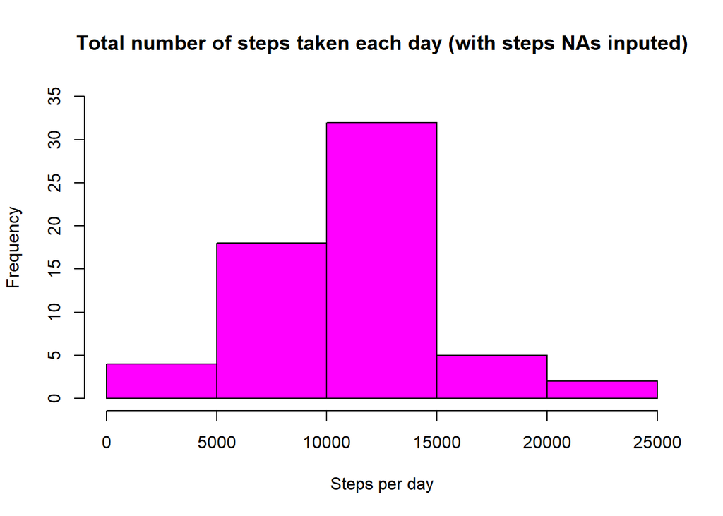

```r
hist(DayStepsImputed$steps, main = "Total number of steps taken each day (with steps NAs inputed)", xlab = "Steps per day", ylab = "Frequency",  xlim=c(0,25000),ylim=c(0,35), col = "magenta")
```

Comparing two histograms, with steps NA’s removed and with steps NA’s imputed:

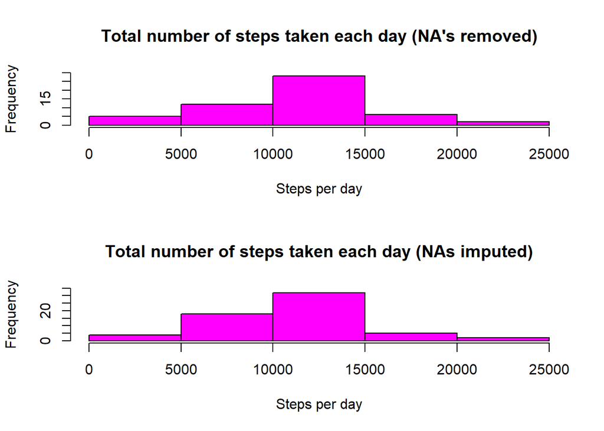

```r
par(mfrow=c(2,1))
hist(DaySteps$steps, main ="Total number of steps taken each day (NA's removed)" , xlab = "Steps per day", ylab = "Frequency", ylim=c(0,30), col = "magenta")
hist(DayStepsImputed$steps, main ="Total number of steps taken each day (NAs imputed)", xlab = "Steps per day", ylab = "Frequency", xlim=c(0,25000), ylim=c(0,35), col = "magenta")
```

# Calculating and reporting the mean and median total number of steps taken per day (with NA imputed):

```r
summary(DayStepsImputed$steps)
```

```
##    Min. 1st Qu.  Median    Mean 3rd Qu.    Max.
##    1207    9418   10733   10733   12807   21279
```

mean total number of steps taken per day (with NA imputed):

```r
TotalDayStepsImputedMean<-mean(DayStepsImputed$steps)
TotalDayStepsImputedMean
```

```
## [1] 10732.64
```

# 10732.64

median total number of steps taken per day (with NA imputed):

```r
TotalDayStepsImputedMedian<-median(DayStepsImputed$steps)
TotalDayStepsImputedMedian
```

```
## [1] 10732.64
```

# 10732.64

# Do these values differ from the estimates from the first part of the assignment? What is the impact of imputing missing data on the estimates of the total daily number of steps?

Yes, there is a difference:both, mean and median have decrased after the imputation of steps with mean, and the mean and median values after the imputation has become equial:

```
          TotalDayStepsMean  = 10766.19 | TotalDayStepsMedian = 10765
    TotalDayStepsImputedMean = 10732.64 | TotalDayStepsImputedMedian = 10732.64
```

## Are there differences in activity patterns between weekdays and weekends?

Make a time series plot (i.e. type = “l”) of the 5-minute interval (x-axis) and the average number of steps taken, averaged across all days (y-axis)

[figure not shown]

```r
library(ggplot2)
DaiylyActivityImputed<- aggregate(steps~interval,ProjectDataImputed, mean)
p<- ggplot(DaylyActivity, aes(  interval, steps,color=steps))+ ggtitle("Daily Activity (with steps NA's imputed)")
p + geom_line(size=.5)+labs(x = "5-minute interval")+labs(y = "Average number of steps taken" ) +theme(axis.text=element_text(color="black",size=13))+theme(panel.background=element_rect(fill="khaki"))+theme(axis.title.x=element_text(color='blue',vjust=1.5),axis.title.y=element_text(color="blue",vjust=1.5), plot.title=element_text(color="blue",size=15,vjust=1),
plot.background=element_rect(fill="lightblue"))
```

# Create a new factor variable in the dataset with two levels – “weekday” and “weekend” indicating whether a given date is a weekday or weekend day:

```r
#Converting date variable to Date format
library(anytime)

ProjectDataImputed$date<-anydate(ProjectDataImputed$date)
head(ProjectDataImputed,3)
```

```
##     steps       date interval
## 1 37.2661 2012-10-01        0
## 2 37.2661 2012-10-01        5
## 3 37.2661 2012-10-01       10
```

```r
class(ProjectDataImputed$date)
```

```
## [1] "Date"
```

```r
#creating weekdays column
ProjectDataImputed$weekdays<-weekdays(ProjectDataImputed$date, abbreviate = FALSE)
head(ProjectDataImputed,3)
```

```
##     steps       date interval weekdays
## 1 37.2661 2012-10-01        0   Monday
## 2 37.2661 2012-10-01        5   Monday
## 3 37.2661 2012-10-01       10   Monday
```

```r
#Create a new factor variable in the dataset with two levels - "weekday" and "weekend" indicating whether a given date is a weekday or weekend day.

#1 duplicating wekdays column as dayofweek column (for check later conversion to "Weekdays" and "Weekends")
library(dplyr)
ProjectDataImputed<-mutate(ProjectDataImputed, dayofweek=weekdays)
head(ProjectDataImputed,3)
```

```
##     steps       date interval weekdays dayofweek
## 1 37.2661 2012-10-01        0   Monday    Monday
## 2 37.2661 2012-10-01        5   Monday    Monday
## 3 37.2661 2012-10-01       10   Monday    Monday
```

```r
#converting names of weekdays to "Weekday" or "Weekend"

ProjectDataFinalImputed<-ProjectDataImputed%>%mutate(weekdays = case_when(
  weekdays == 'Sunday' ~ 'Weekend',
  weekdays == 'Saturday' ~ 'Weekend',
  TRUE ~ 'Weekday'))

#Check conversion to Weekdays :

head(ProjectDataFinalImputed,3)
```

```
##     steps       date interval weekdays dayofweek
## 1 37.2661 2012-10-01        0  Weekday    Monday
## 2 37.2661 2012-10-01        5  Weekday    Monday
## 3 37.2661 2012-10-01       10  Weekday    Monday
```

# Calculate avarage number of steps for weekdays:

```r
DaylyActivityWeekdaysImputedFinal<- aggregate(steps~interval+weekdays, ProjectDataFinalImputed, mean)
head(DaylyActivityWeekdaysImputedFinal,3)
```

```
##   interval weekdays     steps
## 1        0  Weekday 10.081355
## 2        5  Weekday  8.681355
## 3       10  Weekday 10.093182
```

```r
tail(DaylyActivityWeekdaysImputedFinal,3)
```

```
##     interval weekdays     steps
## 574     2345  Weekend  8.612394
## 575     2350  Weekend  4.658262
## 576     2355  Weekend 11.645656
```

## Comparing weekdays and weekends activities:

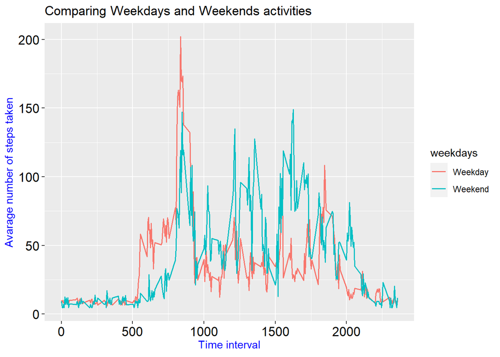

```r
g<-ggplot(DaylyActivityWeekdaysImputedFinal, aes(interval, steps, color=weekdays))+ ggtitle("Comparing Weekdays and Weekends activities")
g + geom_line(size=.6)+ labs(x = "Time interval")+labs(y = "Avarage number of steps taken") +theme(axis.text=element_text(color="black",size=13))+theme(axis.title.x=element_text(color='blue',vjust=1.5), axis.title.y=element_text(color="blue",vjust=1.5))
```

## Yes, there are differences in activity patterns between weekdays and weekends:

More steps, in general, are observed starting from about 1000s 5 minute interval and untill the end of the day, during the weekends, compare to the weekdays, while more steps are observed around 800s 5 mimute interval, during the weekdays, compare to weekends.

# Make a panel plot containing a time series plot (i.e. type = “l”) of the 5-minute interval (x-axis) and the average number of steps taken, averaged across all weekday days or weekend days (y-axis).

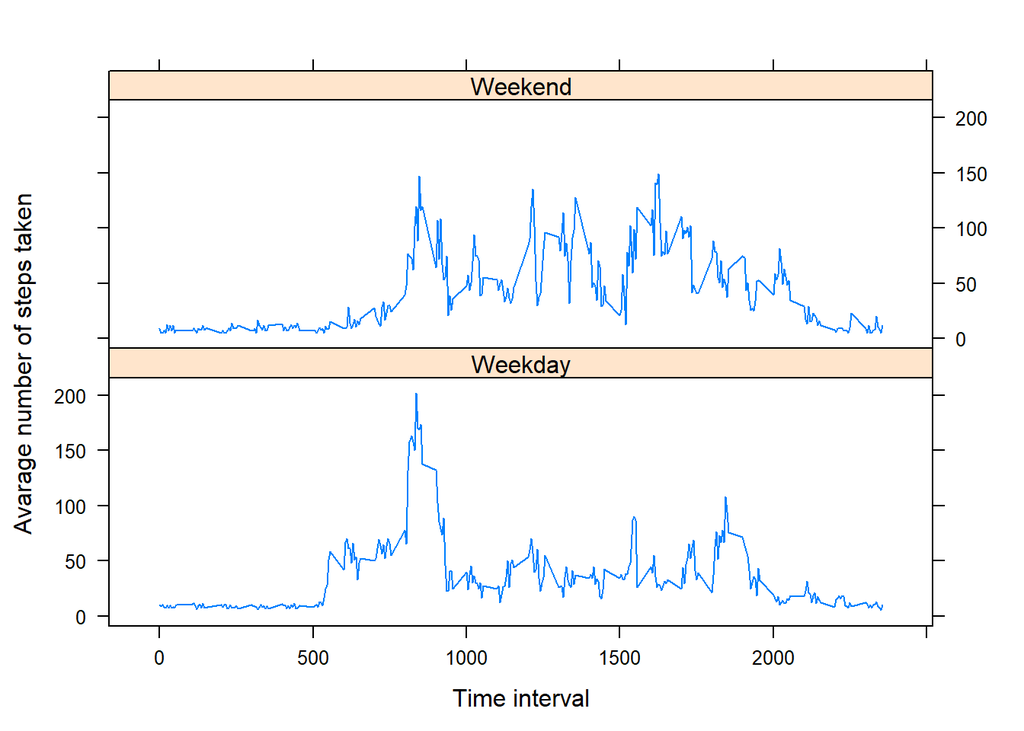

```r
#plot(plotname)
library(lattice)
with(DaylyActivityWeekdaysImputedFinal, xyplot(steps ~ interval | weekdays, type="l", xlab = "Time interval", ylab = "Avarage number of steps taken", layout = c(1, 2)))
```

```r
#for the next step:
library(knitr)
```